Nama : Riofebri Prasetia  
NIM : 221911192  
Kelas : 3SI1

## Bartlett Sphericity Test

Analisis faktor eksplorasi hanya berguna jika matriks korelasi populasi secara statistik berbeda dari matriks identitas. Jika ini sama, variabel-variabelnya sedikit saling terkait, yaitu faktor-faktor spesifik menjelaskan proporsi varians yang lebih besar dan faktor-faktor umum tidak penting. Oleh karena itu, itu harus didefinisikan ketika korelasi antara variabel asli cukup tinggi. Dengan demikian, analisis faktor berguna dalam mengestimasi faktor persekutuan. Dengan pemikiran ini, uji Bartlett Sphericity dapat digunakan. Hipotesisnya adalah:

H0: matriks korelasi populasi sama dengan matriks identitas

H1: matriks korelasi populasi berbeda dengan matriks identitas.

## KMO Test

KMO adalah ukuran kecukupan pengambilan sampel “Kaiser-Meyer-Olkin” dan memeriksa apakah mungkin untuk memfaktorkan variabel utama secara efisien. Matriks korelasi selalu menjadi titik awal. Variabel kurang lebih berkorelasi, tetapi yang lain bisa mempengaruhi korelasi antara dua variabel.Oleh karena itu, dengan KMO, korelasi parsial digunakan untuk mengukur hubungan antara dua variabel dengan menghilangkan pengaruh dari variabel yang tersisa. (sumber: https://github.com/Sarmentor/KMO-Bartlett-Tests-Python)

## Soal 1: 8.11

Perhatikan data sensus yang tercantum pada Tabel 8.5. Misalkan pengamatan pada X5 = nilai median rumah dicatat dalam ribuan, bukan sepuluh ribu dolar; yaitu, kalikan semua angka yang tercantum di kolom keenam meja dengan 10.  
a. Bangun matriks kovarians sampel S untuk data saluran sensus ketika: $X_{5}$ = nilai median rumah dicatat dalam ribuan dolar. (Perhatikan bahwa matriks kovarians ini dapat diperoleh dari matriks kovarians yang diberikan dalam Contoh 8.3 dengan mengalikan elemen-elemen di luar diagonal pada kolom kelima dan baris dengan 10 dan elemen diagonal $s_{55}$ dengan 100. Mengapa?)  
b. Dapatkan pasangan nilai eigen-vektor eigen-value dan dua prinsipal sampel pertama komponen untuk matriks kovarians di Bagian a.  
c. Hitung proporsi varians total yang dijelaskan oleh dua komponen utama pertama yang diperoleh pada Bagian b. Hitung koefisien korelasi, $r_{yi, xk}$ dan menafsirkan komponen ini jika memungkinkan. Bandingkan hasil Anda dengan hasil pada Contoh 8.3. Apa yang bisa Anda katakan tentang efek ini? perubahan skala pada komponen utama?

```r
# Load Data
url1 <- "https://raw.githubusercontent.com/rii92/tugas-APG/main/tugas%20pertemuan%208/tabel_8.5.csv"
census <- read.csv(url1)
census <- subset(census, select = -c(Tract))
#data1 <- as.matrix(data1)
census
```

```
##    totPop medSchoolYears totEmp healServEmp medValHome
## 1   5.935           14.2  2.265        2.27       2.91
## 2   1.523           13.1  0.597        0.75       2.62
## 3   2.599           12.7  1.237        1.11       1.72
## 4   4.009           15.2  1.649        0.81       3.02
## 5   4.687           14.7  2.312        2.50       2.22
## 6   8.044           15.6  3.641        4.51       2.36
## 7   2.766           13.3  1.244        1.03       1.97
## 8   6.538           17.0  2.618        2.39       1.85
## 9   6.451           12.9  3.147        5.52       2.01
## 10  3.314           12.2  1.606        2.18       1.82
## 11  3.777           13.0  2.119        2.83       1.80
## 12  1.530           13.8  0.798        0.84       4.25
## 13  2.768           13.6  1.336        1.75       2.64
## 14  6.585           14.9  2.763        1.91       3.17
```

```r
R_census <- cor(census)
R_census
```

```
##                    totPop medSchoolYears     totEmp healServEmp medValHome
## totPop          1.0000000     0.61019384  0.9707333  0.73998387 -0.1719648
## medSchoolYears  0.6101938     1.00000000  0.4943040  0.09539263  0.1859277
## totEmp          0.9707333     0.49430396  1.0000000  0.84796492 -0.2491624
## healServEmp     0.7399839     0.09539263  0.8479649  1.00000000 -0.3579964
## medValHome     -0.1719648     0.18592771 -0.2491624 -0.35799639  1.0000000
```

terdapat beberapa korelasi lebih dari 0.5. Hal ini menunjukkan ada kemungkinan terdapat multikolinieritas

```r
uji_bart <- function(x)
{
 method <- "Bartlett's test of sphericity"
 data.name <- deparse(substitute(x))
 x <- subset(x, complete.cases(x))
 n <- nrow(x)
 p <- ncol(x)
 chisq <- (1-n+(2*p+5)/6)*log(det(cor(x)))
 df <- p*(p-1)/2
 p.value <- pchisq(chisq, df, lower.tail=FALSE)
 names(chisq) <- "Khi-squared"
 names(df) <- "df"
 return(structure(list(statistic=chisq, parameter=df, p.value=p.value, method=method, data.name=data.name), class="htest"))
}
uji_bart(census)
```

```
##
##  Bartlett's test of sphericity
##
## data:  census
## Khi-squared = 62.552, df = 10, p-value = 1.188e-09
```

dengan tingkat signifikasn 5% maka terdapat multikolinieritas karena p-value kurang dari 0.05

**jawaban a:**

```r
census_a <- census
census_a$medValHome <- census_a$medValHome*10
census_a
```

```
##    totPop medSchoolYears totEmp healServEmp medValHome
## 1   5.935           14.2  2.265        2.27       29.1
## 2   1.523           13.1  0.597        0.75       26.2
## 3   2.599           12.7  1.237        1.11       17.2
## 4   4.009           15.2  1.649        0.81       30.2
## 5   4.687           14.7  2.312        2.50       22.2
## 6   8.044           15.6  3.641        4.51       23.6
## 7   2.766           13.3  1.244        1.03       19.7
## 8   6.538           17.0  2.618        2.39       18.5
## 9   6.451           12.9  3.147        5.52       20.1
## 10  3.314           12.2  1.606        2.18       18.2
## 11  3.777           13.0  2.119        2.83       18.0
## 12  1.530           13.8  0.798        0.84       42.5
## 13  2.768           13.6  1.336        1.75       26.4
## 14  6.585           14.9  2.763        1.91       31.7
```

```r
S_census_a <- cov(census_a)
S_census_a
```

```
##                   totPop medSchoolYears     totEmp healServEmp medValHome
## totPop          4.307556      1.6836802  1.8027760    2.155326  -2.534744
## medSchoolYears  1.683680      1.7674725  0.5880264    0.177978   1.755495
## totEmp          1.802776      0.5880264  0.8006685    1.064828  -1.583390
## healServEmp     2.155326      0.1779780  1.0648280    1.969475  -3.568066
## medValHome     -2.534744      1.7554945 -1.5833901   -3.568066  50.438022
```

```r
XbarCensus <- colMeans(census)
XbarCensus
```

```
##         totPop medSchoolYears         totEmp    healServEmp     medValHome
##       4.323286      14.014286       1.952286       2.171429       2.454286
```

```r
SCensusEx8.3 <- matrix(c(4.308, 1.683, 1.803, 2.155, -0.253,
                         1.683, 1.768, 0.588, 0.177, 0.176,
                         1.803, 0.588, 0.801, 1.065, -0.158,
                         2.155, 0.177, 1.065, 1.970, -0.357,
                         -0.253, 0.176, -0.158, -0.357, 0.504), nrow = 5, byrow = T)
SCensusEx8.3[1:4,5] <- SCensusEx8.3[1:4,5]*10
SCensusEx8.3[5,1:4] <- SCensusEx8.3[5,1:4]*10
SCensusEx8.3[5,5] <- SCensusEx8.3[5,5]*100
SCensusEx8.3
```

```
##        [,1]  [,2]   [,3]   [,4]  [,5]
## [1,]  4.308 1.683  1.803  2.155 -2.53
## [2,]  1.683 1.768  0.588  0.177  1.76
## [3,]  1.803 0.588  0.801  1.065 -1.58
## [4,]  2.155 0.177  1.065  1.970 -3.57
## [5,] -2.530 1.760 -1.580 -3.570 50.40
```

```r
S_census_a
```

```
##                   totPop medSchoolYears     totEmp healServEmp medValHome
## totPop          4.307556      1.6836802  1.8027760    2.155326  -2.534744
## medSchoolYears  1.683680      1.7674725  0.5880264    0.177978   1.755495
## totEmp          1.802776      0.5880264  0.8006685    1.064828  -1.583390
## healServEmp     2.155326      0.1779780  1.0648280    1.969475  -3.568066
## medValHome     -2.534744      1.7554945 -1.5833901   -3.568066  50.438022
```

matriks kovarians hasil transformasi variabel medValHome di kali 10 dengan perkalian secara manual kovarians dari contoh soal memiliki hasil yang sama

**jawaban b**

```r
eigenCensusAfterTransf <- eigen(S_census_a)
eigenValueCensusA <- eigenCensusAfterTransf$values
eigenValueCensusA
```

```
## [1] 50.96935726  6.64988991  1.41999710  0.22978608  0.01416317
```

```r
eigenVectorCensusA <- eigenCensusAfterTransf$vectors
eigenVectorCensusA
```

```
##             [,1]       [,2]        [,3]         [,4]         [,5]
## [1,]  0.05765977 0.78220765  0.02307185  0.541282426 -0.302171422
## [2,] -0.03281610 0.35032828  0.76422159 -0.540439691 -0.009137870
## [3,]  0.03467366 0.32717525 -0.10109097  0.051177198  0.937504990
## [4,]  0.07557524 0.39085238 -0.63207658 -0.642117054 -0.172301138
## [5,] -0.99432619 0.07491367 -0.07545108  0.002204195  0.002375237
```

2 komponen pertama yaitu:  
$y_{1} = 0.058x_{1} - 0.033x_{2} + 0.035x_{3} + 0.076x_{4} -0.994x_{5}$  
$y_{2} = 0.782x_{1} + 0.350x_{2} + 0.327x_{3} + 0.391x_{4} + 0.075x_{5}$

**jawaban c**

```r
#mencari nilai proporsi varians kumulatif


#sebelum transformasi
library(factoextra)
summary(princomp(census, cor = FALSE), loadings = TRUE)
```

```
## Importance of components:
##                           Comp.1    Comp.2     Comp.3     Comp.4      Comp.5
## Standard deviation     2.5369267 1.2874914 0.60151291 0.46166437 0.114646905
## Proportion of Variance 0.7413268 0.1909337 0.04167579 0.02454972 0.001513975
## Cumulative Proportion  0.7413268 0.9322605 0.97393630 0.99848603 1.000000000
##
## Loadings:
##                Comp.1 Comp.2 Comp.3 Comp.4 Comp.5
## totPop          0.781                0.542  0.302
## medSchoolYears  0.306  0.764 -0.162 -0.545
## totEmp          0.334                      -0.937
## healServEmp     0.426 -0.579  0.220 -0.636  0.172
## medValHome             0.262  0.962
```

```r
#setelah transformasi
library(factoextra)
summary(princomp(census_a, cor = FALSE), loadings = TRUE)
```

```
## Importance of components:
##                           Comp.1    Comp.2     Comp.3      Comp.4      Comp.5
## Standard deviation     6.8795849 2.4849342 1.14828948 0.461922929 0.114680047
## Proportion of Variance 0.8597607 0.1121716 0.02395278 0.003876075 0.000238907
## Cumulative Proportion  0.8597607 0.9719322 0.99588502 0.999761093 1.000000000
##
## Loadings:
##                Comp.1 Comp.2 Comp.3 Comp.4 Comp.5
## totPop                 0.782         0.541  0.302
## medSchoolYears         0.350  0.764 -0.540
## totEmp                 0.327 -0.101        -0.938
## healServEmp            0.391 -0.632 -0.642  0.172
## medValHome     -0.994
```

```r
#nilai PCA sebelum transformasi
prcomp(census, scale = FALSE)$rotation
```

```
##                        PC1         PC2          PC3         PC4          PC5
## totPop         -0.78120807  0.07087183 -0.003656607  0.54171007  0.302039670
## medSchoolYears -0.30564856  0.76387277  0.161817438 -0.54479937  0.009279632
## totEmp         -0.33444840 -0.08290788 -0.014841008  0.05101636 -0.937255367
## healServEmp    -0.42600795 -0.57945799 -0.220453468 -0.63601254  0.172145212
## medValHome      0.05435431  0.26235528 -0.961759720  0.05127599 -0.024583093
```

```r
#nilai PCA setelah transformasi
prcomp(census_a, scale = FALSE)$rotation
```

```
##                        PC1         PC2         PC3          PC4          PC5
## totPop          0.05765977 -0.78220765 -0.02307185  0.541282426 -0.302171422
## medSchoolYears -0.03281610 -0.35032828 -0.76422159 -0.540439691 -0.009137870
## totEmp          0.03467366 -0.32717525  0.10109097  0.051177198  0.937504990
## healServEmp     0.07557524 -0.39085238  0.63207658 -0.642117054 -0.172301138
## medValHome     -0.99432619 -0.07491367  0.07545108  0.002204195  0.002375237
```

```r
#rhoYX sebelum transformasi
eigenCensus <- eigen(cov(census))
eigenVectorCensus <- eigenCensus$vectors
eigenValueCensus <- eigenCensus$values
S_census <- cov(census)

rhoyx <- matrix(0, ncol = ncol(census), nrow = ncol(census))
for(i in 1:ncol(census))
{
  for(j in 1:ncol(census)){
   rhoyx[i,j] <- eigenVectorCensus[i,j]*sqrt(eigenValueCensus[i])/sqrt(S_census[j,j])
  }
}
rhoyx
```

```
##              [,1]        [,2]        [,3]         [,4]         [,5]
## [1,]  0.990949503 -0.14034520  0.01075851  1.016229870  1.119657565
## [2,]  0.196763062 -0.76768201 -0.24162152 -0.518678274  0.017457755
## [3,]  0.100589111  0.03892753  0.01035319  0.022691936 -0.823789419
## [4,]  0.098337906  0.20881626  0.11803458 -0.217124674  0.116127380
## [5,] -0.003115826 -0.02347838  0.12787772  0.004347039 -0.004118245
```

```r
#rhoYX setelah transformasi
rhoyx <- matrix(0, ncol = ncol(census_a), nrow = ncol(census_a))
for(i in 1:ncol(census_a))
{
  for(j in 1:ncol(census_a)){
   rhoyx[i,j] <- eigenVectorCensusA[i,j]*sqrt(eigenValueCensusA[i])/sqrt(S_census_a[j,j])
  }
}
rhoyx
```

```
##             [,1]        [,2]        [,3]          [,4]          [,5]
## [1,]  0.19834077 4.200493349  0.18408174  2.7536155141 -3.037589e-01
## [2,] -0.04077357 0.679526022  2.20242005 -0.9930686193 -3.317975e-03
## [3,]  0.01990801 0.293256623 -0.13462624  0.0434555273  1.573035e-01
## [4,]  0.01745524 0.140928326 -0.33861421 -0.2193314255 -1.162977e-02
## [5,] -0.05701559 0.006706022 -0.01003504  0.0001869197  3.980229e-05
```

untuk setelah transformasi:

1. Komponen pertama menjelaskan proporsi dari total varians kumulatif ialah sebesar 85,98%.
2. Komponen kedua menjelaskan proporsi dari total varians kumulatif ialah sebesar 97.19%
3. Dari ini peringkasan variabel dari 5 komponen utama menjadi 2 komponen pertama utama bisa dilakukan atau wajar
4. korelasi variabel $X_{3}$ dalam $Y_{1}$ hampir sama besar dengan variabel $X_{4}$ dalam $Y_{1}$. Hal ini menunjukkan kedua variabel sangat penting untuk komponen utama
5. Pada korelasi variabel $Y_{1}$ sebelum transformasi terdapat variabel X yang korelasi nya lebih tinggi dibanding variabel X yang lainnya dalam Y1. Perbedaan ini mungkin karena efek dari transformasi

## Soal 2: 8.12

Perhatikan data polusi udara yang tercantum pada Tabel 1.5. Tugas Anda adalah meringkas data ini dalam kurang dari $p$ = 7 dimensi jika memungkinkan. Lakukan analisis komponen utama data menggunakan matriks kovarians **S** dan matriks korelasi **R**. Apa yang telah Anda pelajari? Apakah ada bedanya matriks mana yang dipilih untuk analisis? Dapatkah data diringkas dalam tiga atau lebih sedikit dimensi? Dapatkah Anda menginterpretasikan komponen utama?

```r
url2 <- "https://raw.githubusercontent.com/rii92/tugas-APG/main/tugas%20pertemuan%208/table%201.5.csv"
airPollution <- read.csv(url2)
airPollution
```

```
##    wind solarRadiation co NO NO2 O3 HC
## 1     8             98  7  2  12  8  2
## 2     7            107  4  3   9  5  3
## 3     7            103  4  3   5  6  3
## 4    10             88  5  2   8 15  4
## 5     6             91  4  2   8 10  3
## 6     8             90  5  2  12 12  4
## 7     9             84  7  4  12 15  5
## 8     5             72  6  4  21 14  4
## 9     7             82  5  1  11 11  3
## 10    8             64  5  2  13  9  4
## 11    6             71  5  4  10  3  3
## 12    6             91  4  2  12  7  3
## 13    7             72  7  4  18 10  3
## 14   10             70  4  2  11  7  3
```

[output cut: 28 more lines]

```r
R_airPol <- cor(airPollution)
R_airPol
```

```
##                      wind solarRadiation         co          NO        NO2
## wind            1.0000000    -0.10144191 -0.1938032 -0.26954261 -0.1098249
## solarRadiation -0.1014419     1.00000000  0.1827934 -0.07356907  0.1157320
## co             -0.1938032     0.18279338  1.0000000  0.50215246  0.5565838
## NO             -0.2695426    -0.07356907  0.5021525  1.00000000  0.2968981
## NO2            -0.1098249     0.11573199  0.5565838  0.29689814  1.0000000
## O3             -0.2535928     0.31912373  0.4109288 -0.13395214  0.1666422
## HC              0.1560979     0.05201044  0.1660323  0.23470432  0.4477678
##                        O3         HC
## wind           -0.2535928 0.15609793
## solarRadiation  0.3191237 0.05201044
## co              0.4109288 0.16603235
## NO             -0.1339521 0.23470432
## NO2             0.1666422 0.44776780
## O3              1.0000000 0.15445056
## HC              0.1544506 1.00000000
```

Karena terdapat korelasi antar variabel lebih dari 5 atau kurang dari -5, maka terdapat multikolinieritas.

```r
uji_bart <- function(x)
{
 method <- "Bartlett's test of sphericity"
 data.name <- deparse(substitute(x))
 x <- subset(x, complete.cases(x))
 n <- nrow(x)
 p <- ncol(x)
 chisq <- (1-n+(2*p+5)/6)*log(det(cor(x)))
 df <- p*(p-1)/2
 p.value <- pchisq(chisq, df, lower.tail=FALSE)
 names(chisq) <- "Khi-squared"
 names(df) <- "df"
 return(structure(list(statistic=chisq, parameter=df, p.value=p.value, method=method, data.name=data.name), class="htest"))
}

uji_bart(airPollution)
```

```
##
##  Bartlett's test of sphericity
##
## data:  airPollution
## Khi-squared = 70.527, df = 21, p-value = 2.892e-07
```

Dalam signifikan 5%. p-value kurang dari 5% maka bisa kita simpulkan terdapat multikolinieritas antar variabel. Selanjutnya akan di lakukan analisis PCA

```r
#data summary air pollution
library(pastecs)
stat.desc(airPollution)
```

```
##                     wind solarRadiation          co         NO         NO2
## nbr.val       42.0000000     42.0000000  42.0000000 42.0000000  42.0000000
## nbr.null       0.0000000      0.0000000   0.0000000  0.0000000   0.0000000
## nbr.na         0.0000000      0.0000000   0.0000000  0.0000000   0.0000000
## min            5.0000000     30.0000000   2.0000000  1.0000000   5.0000000
## max           10.0000000    107.0000000   7.0000000  5.0000000  21.0000000
## range          5.0000000     77.0000000   5.0000000  4.0000000  16.0000000
## sum          315.0000000   3102.0000000 191.0000000 92.0000000 422.0000000
## median         8.0000000     76.5000000   4.0000000  2.0000000   9.5000000
## mean           7.5000000     73.8571429   4.5476190  2.1904762  10.0476190
## SE.mean        0.2439750      2.6749085   0.1903673  0.1677829   0.5201541
## CI.mean.0.95   0.4927175      5.4020872   0.3844545  0.3388444   1.0504725
## var            2.5000000    300.5156794   1.5220674  1.1823461  11.3635308
## std.dev        1.5811388     17.3353881   1.2337209  1.0873574   3.3709837
## coef.var       0.2108185      0.2347151   0.2712894  0.4964023   0.3355007
##                       O3          HC
## nbr.val       42.0000000  42.0000000
## nbr.null       0.0000000   0.0000000
## nbr.na         0.0000000   0.0000000
## min            2.0000000   2.0000000
## max           25.0000000   5.0000000
## range         23.0000000   3.0000000
## sum          395.0000000 130.0000000
## median         8.5000000   3.0000000
## mean           9.4047619   3.0952381
## SE.mean        0.8588269   0.1067388
## CI.mean.0.95   1.7344361   0.2155634
## var           30.9785134   0.4785134
## std.dev        5.5658345   0.6917466
## coef.var       0.5918102   0.2234874
```

```r
#untuk matrix kovarians
S_airPol <- cov(airPollution)
S_airPol
```

```
##                      wind solarRadiation         co         NO        NO2
## wind            2.5000000     -2.7804878 -0.3780488 -0.4634146 -0.5853659
## solarRadiation -2.7804878    300.5156794  3.9094077 -1.3867596  6.7630662
## co             -0.3780488      3.9094077  1.5220674  0.6736353  2.3147503
## NO             -0.4634146     -1.3867596  0.6736353  1.1823461  1.0882695
## NO2            -0.5853659      6.7630662  2.3147503  1.0882695 11.3635308
## O3             -2.2317073     30.7909408  2.8217189 -0.8106852  3.1265970
## HC              0.1707317      0.6236934  0.1416957  0.1765389  1.0441347
##                        O3        HC
## wind           -2.2317073 0.1707317
## solarRadiation 30.7909408 0.6236934
## co              2.8217189 0.1416957
## NO             -0.8106852 0.1765389
## NO2             3.1265970 1.0441347
## O3             30.9785134 0.5946574
## HC              0.5946574 0.4785134
```

```r
eigenAirPol <- eigen(S_airPol)
eigenValueAirPol <- eigenAirPol$values
eigenVectorsAirPol <- eigenAirPol$vectors

eigenValueAirPol
```

```
## [1] 304.2578640  28.2761046  11.4644830   2.5243296   1.2795247   0.5287288
## [7]   0.2096157
```

```r
eigenVectorsAirPol
```

```
##              [,1]        [,2]        [,3]          [,4]          [,5]
## [1,]  0.010039244  0.07622439  0.03087761  0.9203045748  0.3423859285
## [2,] -0.993199405  0.11615518  0.00659069 -0.0002118679  0.0022391022
## [3,] -0.014062314 -0.09956775 -0.18282641 -0.1382922410  0.6500776063
## [4,]  0.004710175  0.01320423 -0.13021553 -0.3277842624  0.6431560485
## [5,] -0.024255644 -0.15038113 -0.95526318  0.1023719020 -0.2065840405
## [6,] -0.112429558 -0.97335904  0.16981025  0.0632480276 -0.0002935726
## [7,] -0.002340785 -0.02382046 -0.08519558  0.1095073458  0.0619613872
##              [,6]         [,7]
## [1,]  0.011779079 -0.169729925
## [2,]  0.003353218 -0.001781987
## [3,] -0.563893916  0.443577538
## [4,]  0.497513370 -0.462855916
## [5,] -0.009009299 -0.105029951
## [6,]  0.051067254 -0.066992404
## [7,]  0.657012233  0.738019426
```

```r
#The proportion of total variance accounted
library(roperators)
propTotVar <- matrix(0, ncol = ncol(airPollution), nrow = 1)
temp = 0
for(i in 1:ncol(airPollution))
{
  temp %+=% eigenValueAirPol[i]
  prop = (temp/sum(eigenValueAirPol)) * 100
  propTotVar[1,i] = prop
}
propTotVar
```

```
##         [,1]     [,2]    [,3]     [,4]     [,5]     [,6] [,7]
## [1,] 87.2948 95.40751 98.6968 99.42105 99.78816 99.93986  100
```

The proportion of total variance accounted for by the first principal component is 87.29%

```r
rhoyx <- matrix(0, ncol = ncol(airPollution), nrow = ncol(airPollution))
for(i in 1:ncol(airPollution))
{
  for(j in 1:ncol(airPollution)){
   coryx <- eigenVectorsAirPol[i,j]*sqrt(eigenValueAirPol[i])/sqrt(S_airPol[j,j])
   rhoyx[i,j] <-coryx
  }
}
rhoyx
```

```
##               [,1]          [,2]        [,3]         [,4]          [,5]
## [1,]  0.1107520899  0.0766975185  0.43656377 14.763188796  1.771659e+00
## [2,] -3.3402289547  0.0356299176  0.02840689 -0.001036102  3.532052e-03
## [3,] -0.0301136932 -0.0194474372 -0.50176368 -0.430628470  6.529588e-01
## [4,]  0.0047330386  0.0012101872 -0.16769452 -0.478948494  3.031327e-01
## [5,] -0.0173527033 -0.0098126000 -0.87585141  0.106495876 -6.932094e-02
## [6,] -0.0517043382 -0.0408278006  0.10008372  0.042295207 -6.332501e-05
## [7,] -0.0006778029 -0.0006291128 -0.03161637  0.046108697  8.415432e-03
##              [,6]        [,7]
## [1,]  0.036914922 -4.27988690
## [2,]  0.003203622 -0.01369832
## [3,] -0.343039681  2.17119960
## [4,]  0.142019342 -1.06309436
## [5,] -0.001830986 -0.17174751
## [6,]  0.006671580 -0.07041984
## [7,]  0.054044946  0.48846413
```

dalam Y1 dan X7 terdapat korelasi paling kecil yang berarti ada kemungkinan variabel X7 dalam Y1 ini tidak di anggap terlalu penting

```r
#untuk matrix korelasi
eigenAirPolCor <- eigen(cor(airPollution))
eigenValueAirPolCor <- eigenAirPolCor$values
eigenVectorsAirPolCor <- eigenAirPolCor$vectors
eigenVectorsAirPolCor
```

```
##            [,1]         [,2]       [,3]         [,4]        [,5]         [,6]
## [1,]  0.2368211  0.278445138  0.6434744  0.172719491  0.56053441 -0.223579220
## [2,] -0.2055665 -0.526613869  0.2244690  0.778136601 -0.15613432 -0.005700851
## [3,] -0.5510839 -0.006819502 -0.1136089  0.005301798  0.57342221 -0.109538907
## [4,] -0.3776151  0.434674253 -0.4070978  0.290503052 -0.05669070 -0.450234781
## [5,] -0.4980161  0.199767367  0.1965567 -0.042428178  0.05021430  0.744968707
## [6,] -0.3245506 -0.566973655  0.1598465 -0.507915905  0.08024349 -0.330583071
## [7,] -0.3194032  0.307882771  0.5410484 -0.143082348 -0.56607057 -0.266469812
##             [,7]
## [1,] -0.24146701
## [2,] -0.01126548
## [3,]  0.58524622
## [4,] -0.46088973
## [5,] -0.33784371
## [6,] -0.41707805
## [7,]  0.31391372
```

```r
eigenValueAirPolCor
```

```
## [1] 2.3367826 1.3860007 1.2040659 0.7270865 0.6534765 0.5366888 0.1558989
```

```r
#The proportion of total variance accounted for matrx corellation
library(roperators)
propTotVarCor <- matrix(0, ncol = ncol(airPollution), nrow = 1)
temp = 0
for(i in 1:ncol(airPollution))
{
  temp %+=% eigenValueAirPolCor[i]
  prop = (temp/sum(eigenValueAirPolCor)) * 100
  propTotVarCor[1,i] = prop
}
propTotVarCor
```

```
##          [,1]     [,2]     [,3]     [,4]     [,5]     [,6] [,7]
## [1,] 33.38261 53.18262 70.38356 80.77051 90.10589 97.77287  100
```

The proportion of total variance accounted for by the fourth principal component is 80.77%

```r
rhoyxCor <- matrix(0, ncol = ncol(airPollution), nrow = ncol(airPollution))
for(i in 1:ncol(airPollution))
{
  for(j in 1:ncol(airPollution)){
   coryx <- eigenVectorsAirPolCor[i,j]*sqrt(eigenValueAirPolCor[i])/sqrt(S_airPol[j,j])
   rhoyxCor[i,j] <-coryx
  }
}
rhoyxCor
```

```
##             [,1]          [,2]        [,3]         [,4]        [,5]
## [1,]  0.22895996  0.0245536030  0.79730312  0.242816501  0.25418785
## [2,] -0.15306086 -0.0357635354  0.21420081  0.842490961 -0.05452849
## [3,] -0.38244840 -0.0004316624 -0.10104635  0.005350273  0.18665645
## [4,] -0.20364435  0.0213807721 -0.28136808  0.227809286 -0.01433997
## [5,] -0.25461760  0.0093154959  0.12879114 -0.031542569  0.01204164
## [6,] -0.15037434 -0.0239602075  0.09491777 -0.342200596  0.01743871
## [7,] -0.07976104  0.0070125086  0.17315729 -0.051955955 -0.06630336
##              [,6]        [,7]
## [1,] -0.061405929 -0.53360504
## [2,] -0.001205844 -0.01917274
## [3,] -0.021595499  0.92836064
## [4,] -0.068976601 -0.56812386
## [5,]  0.108198875 -0.39480606
## [6,] -0.043512255 -0.44170423
## [7,] -0.018903374  0.17917807
```

pada variabel X dalam Y1 sebagian besar nilai korelasi nya hampir sama yang menandakan hampir semua variabel X dalam Y1 sama pentingnya

## Soal 3: 8.14

Lakukan analisis komponen utama menggunakan matriks kovarians sampel dari data keringat yang diberikan dalam Contoh 5.2. Buatlah plot $Q-Q$ untuk setiap komponen utama yang penting. Apakah ada pengamatan yang mencurigakan? Menjelaskan.

```r
url3 <- "https://raw.githubusercontent.com/rii92/tugas-APG/main/tugas%20pertemuan%208/table%205.1.csv"
sweat <- read.csv(url3)
sweat <- subset(sweat, select = -c(Individual))
sweat
```

```
##    SweatRate Sodium Potassium
## 1        3.7   48.5       9.3
## 2        5.7   65.1       8.0
## 3        3.8   47.2      10.9
## 4        3.2   53.2      12.0
## 5        3.1   55.5       9.7
## 6        4.6   36.1       7.9
## 7        2.4   24.8      14.0
## 8        7.2   33.1       7.6
## 9        6.7   47.4       8.5
## 10       5.4   54.1      11.3
## 11       3.9   36.9      12.7
## 12       4.5   58.8      12.3
## 13       3.5   27.8       9.8
## 14       4.5   40.2       8.4
## 15       1.5   13.5      10.1
## 16       8.5   56.4       7.1
## 17       4.5   71.6       8.2
## 18       6.5   52.8      10.9
## 19       4.1   44.1      11.2
## 20       5.5   40.9       9.4
```

```r
miu0Sweat <- c(4, 50, 10)
alphaSweat <- 0.1
n_sweat <- nrow(sweat)
p_sweat <- ncol(sweat)
```

```r
XbarSweat <- colMeans(sweat)
XbarSweat
```

```
## SweatRate    Sodium Potassium
##     4.640    45.400     9.965
```

```r
S_sweat <- cov(sweat)
S_sweat
```

```
##           SweatRate   Sodium Potassium
## SweatRate  2.879368  10.0100 -1.809053
## Sodium    10.010000 199.7884 -5.640000
## Potassium -1.809053  -5.6400  3.627658
```

```r
SInverseSweat <- solve(S_sweat)
SInverseSweat
```

```
##             SweatRate       Sodium    Potassium
## SweatRate  0.58615531 -0.022085719  0.257968742
## Sodium    -0.02208572  0.006067227 -0.001580929
## Potassium  0.25796874 -0.001580929  0.401846765
```

```r
R <- cor(sweat)
R
```

```
##            SweatRate     Sodium  Potassium
## SweatRate  1.0000000  0.4173499 -0.5597440
## Sodium     0.4173499  1.0000000 -0.2094984
## Potassium -0.5597440 -0.2094984  1.0000000
```

pada matrix korelasi terdapat korelasi kurang dari -5, hal ini kemungkinan terdapat multikolinieritas

```r
T2_sweat <- n_sweat*(XbarSweat-miu0Sweat)%*%SInverseSweat%*%(XbarSweat-miu0Sweat)
T2_sweat
```

```
##          [,1]
## [1,] 9.738773
```

```r
C2_sweat <- (n_sweat-1)*p_sweat*qf(p = 1-alphaSweat, df1 = p_sweat, df2 = n_sweat-p_sweat)/(n_sweat-p_sweat)
C2_sweat
```

```
## [1] 8.172573
```

```r
eigenSweat <- eigen(cov(sweat))
eigenValueSweat <- eigenSweat$values
eigenVectorsSweat <- eigenSweat$vectors
eigenValueSweat
```

```
## [1] 200.462464   4.531591   1.301392
```

```r
eigenVectorsSweat
```

```
##             [,1]        [,2]        [,3]
## [1,] -0.05084144 -0.57370364  0.81748351
## [2,] -0.99828352  0.05302042 -0.02487655
## [3,]  0.02907156  0.81734508  0.57541452
```

```r
#Analisis PCA
summary(princomp(sweat, cor = FALSE), loadings = TRUE)
```

```
## Importance of components:
##                            Comp.1     Comp.2      Comp.3
## Standard deviation     13.7999761 2.07485204 1.111900514
## Proportion of Variance  0.9717251 0.02196651 0.006308391
## Cumulative Proportion   0.9717251 0.99369161 1.000000000
##
## Loadings:
##           Comp.1 Comp.2 Comp.3
## SweatRate         0.574  0.817
## Sodium     0.998
## Potassium        -0.817  0.575
```

komponen utama pertama memiliki proporsi total varians kumulatif sebesar 97.17%

```r
dataPcaSweat <- matrix(0, nrow = n_sweat, ncol = p_sweat)
for(i in 1:p_sweat){
  for(j in 1:n_sweat){
    dataPcaSweat[j,i] = eigenVectorsSweat[,i]%*%t(sweat[j,])
  }
}

dataPcaSweat
```

```
##            [,1]      [,2]      [,3]
##  [1,] -48.33450  8.050096  7.169531
##  [2,] -65.04548  6.720279  7.643509
##  [3,] -46.99530  9.231551  8.204283
##  [4,] -52.92252 10.792976  8.197489
##  [5,] -55.28035  9.092399  6.735071
##  [6,] -36.04224  5.732027  7.408155
##  [7,] -24.47245 11.380849  9.400825
##  [8,] -33.18830  3.836132  9.435618
##  [9,] -47.41217  5.616787  9.189015
## [10,] -53.95317  9.006405  9.570774
## [11,] -36.66573 10.099292  9.578006
## [12,] -58.57028 10.589279  9.293533
## [13,] -27.64533  7.475987  7.808687
## [14,] -40.11558  6.415453  7.512121
## [15,] -13.25947  8.110406  6.702079
## [16,] -56.52893  3.917021  9.631016
## [17,] -71.46750  7.916826  6.615914
## [18,] -52.72296  7.979466 10.272179
## [19,] -43.90715  9.140281  8.699269
## [20,] -40.83615  6.696209  8.887605
```

```
## [1] "QQ-Plot untuk Y 1"
```

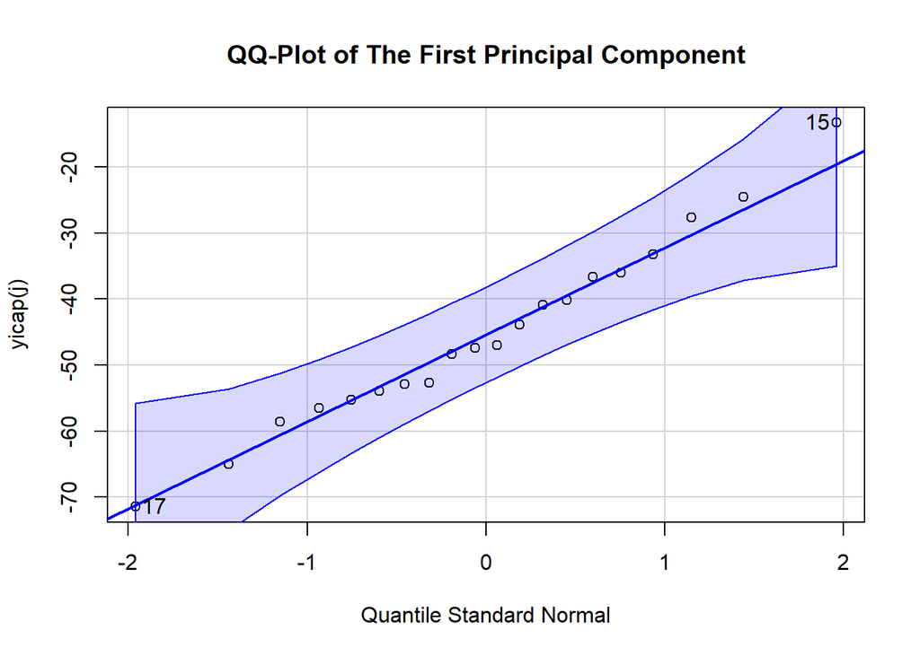

```
## [1] "QQ-Plot untuk Y 2"
```

[figure not shown]

```
## [1] "QQ-Plot untuk Y 3"
```

[figure not shown]

```r
#QQ-Plot
library(car)
for(i in 1:p_sweat){
print(paste("QQ-Plot untuk Y",i))
#qqnorm(dataPca[,i])
#qqline(dataPca[,i])
qqPlot(dataPcaSweat[,i], main = "QQ-Plot of The First Principal Component", xlab
= "Quantile Standard Normal", ylab = "yicap(j)")
}
```

Dari hasil bisa kita lihat QQ plot untuk data PCA yang di dapat yaitu tanpa outlier, artinya tidak ada pengamatan yang mencurigakan